# Perfekte KW-Patrone mit Titegroup

# Zielsetzung

Im Rahmen der Zielsetzung “Deutscher Meister”-Werden beschreibt soll dieses Dokument den Erkenntnisprozess zur Findung der perfekten Match-Patrone beschreiben.

1. Perfekte Match-Munition entwickeln. Eine perfekte Matchpatrone soll aus der PPQ einen Streukreis <= 6cm und aus der HPS einen Streukreis <= 2.5cm erreichen. Weitere Ziele für die perfekte Patrone sind geringe Herstellungskosten und ein möglichst geringes Hochschlagen der Waffe bei sicherem Erreichen des Mindestimpulses. Denkbar ist, dass die Zielstellung nicht mit einem Patronentyp erreicht wird, sondern das für unterschiedliche Disziplinen verschiedene Munitionssorten benutzt werden müssen.
2. Fehler bzw. Fehlerbereiche finden
3. Untersuchung der Arbeitsmethodik um Fehlerquellen auszuschließen
4. Statistische Rechnungen und Methoden erlernen und verstehen

## Pulverschieber MP

### Beschreibung

- Dillon 650 XL mit Pulverschieber/Pulverfüller

### Prüfung der Dosiergenauigkeit

Zur Prüfung Hülsen 35 mit 3.1gr Pulver Titegroup befüllt und anschließend das Pulver mit der Waage MW gewogen. Aus den Messergebnissen lassen sich ableiten:

- Mittelwert = 3.15 bei 35 Proben und einer Standardabweichung 0.05
- Min/Max/Spannweite = 3.08/3.3/0.22
- Median = 3.14
- Modalwert (häufigster Messwert) = 3.1
- Fehlerzahl (Abweichung > 2fache SD) = 3/100

Die Messwerte im Einzelnen:

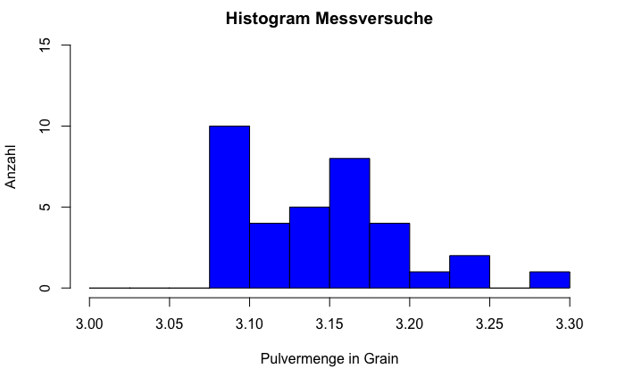

# Test mit Speer 124gr TMJ mit einer Ziel-OAL 30.00 und 3.9gr Titegroup

- Mittelwert = 30.03 bei 49 Proben und einer Standardabweichung 0.075
- Min/Max/Spannweite = 29.84/30.22/0.38
- Median = 30.02
- Modalwert (häufigster Messwert) = 30, 30.04
- Fehlerzahl (Abweichung > 2fache SD) = 5/100

Die Messwerte im Einzelnen:

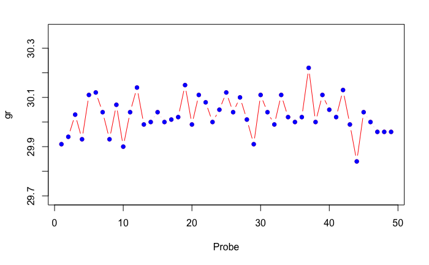

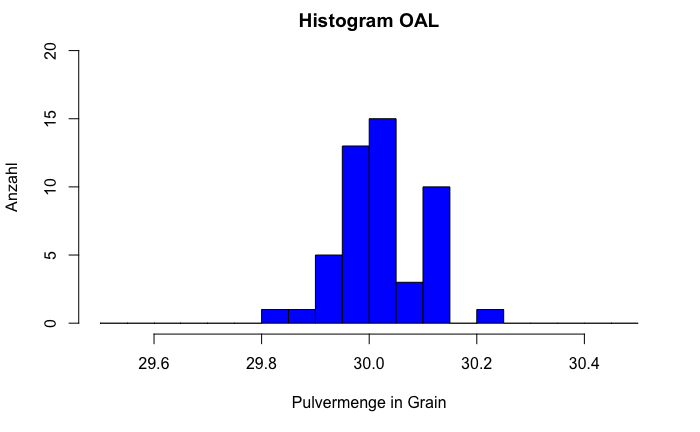